# Berkeley Unified Numident Mortality Database Codebook

| Page | Variable | Label |
| --- | --- | --- |
|  |  | Social Security Number |
|  |  | First Name |
|  |  | Middle Name |
|  |  | Last Name |
|  |  | Sex |
|  |  | Race on First Application |
|  |  | First Race: Application Year |
|  |  | First Race: Application Month |
|  |  | Race on Last Application |
|  |  | Last Race: Application Year |
|  |  | Last Race: Application Month |
|  |  | Change in Race Response Flag |
|  |  | Place of Birth |
|  |  | Year of Birth |
|  |  | Month of Birth |
|  |  | Day of Birth |
|  |  | Year of Death |
|  |  | Month of Death |
|  |  | Day of Death |
|  |  | Age at Death (Years) |
|  |  | ZIP Code of Residence at Time of Death |
|  |  | State where Social Security Number Issued |
|  |  | Father’s First Name |
|  |  | Father’s Middle Name |
|  |  | Father’s Last Name |
|  |  | Mother’s First Name |
|  |  | Mother’s Middle Name |
|  |  | Mother’s Last Name |
|  |  | Age at First Social Security Application |
|  |  | Number of Applications |
|  |  | Number of Claims |
|  |  | High-Coverage Sub-Sample Weight |
|  |  | High-Coverage “Complete Case” Sub-Sample Weight |

**ssn**

**Label**: Social Security Number

**Description**: ssn reports a person’s Social Security number, as recorded in the Numident death records. Uniquely identifies all records in the dataset.

**fname**

**Label**: First Name

**Description**: fname reports the first 16 letters of the person’s first name, as recorded in the Numident death records.

**mname**

**Label:** Middle Name

**Description**: mname reports the first 16 letters of the person’s middle name, as recorded in the Numident death records.

**lname**

**Label:** Last Name

**Description**: lname reports the first 21 letters of the person’s last name, as recorded in the Numident death records.

**sex**

**Label:** Sex

**Description**: sex reports a person’s sex, as recorded in the Numident death, application, or claims Records.

| sex | label | n | freq % |
| --- | --- | --- | --- |
| 1 | Men | 25769568 | 52.20 |
| 2 | Women | 22686047 | 46.00 |
| NA | Missing | 882212 | 1.79 |

**race_first**

**Label**: race first

**Note**: Before 1980, the race schema in the Social Security application form contained three categories: White, Black, and Other. In 1980, the SSA added three categories: (1) Asian, Asian American, or Pacific Islander, (2) Hispanic, and (3) North American Indian or Alaskan Native. They also removed the Other category.

| race_first | label | n | freq % |
| --- | --- | --- | --- |
| 1 | White | 28850917 | 58.476 |
| 2 | Black | 4066081 | 8.241 |
| 3 | Other | 689360 | 1.397 |
| 4 | Asian, Asian American, or Pacific Islander | 207656 | 0.421 |
| 5 | Hispanic | 286517 | 0.581 |
| 6 | North American Indian or Alaskan Native | 17485 | 0.035 |
| NA | Missing | 15219811 | 30.848 |

**race_first_cyear**

**Label:** First Race: Application Year

**race_first_cmonth**

**Label:** First Race: Application Month

**Description**: race_first_cmonth is a numeric variable reporting the month of the application on which a person reported their first race.

**race_last**

**Label**: race last

**Description**: race_last reports a person’s race, as recorded on their most recent application entry.

**Note**: Before 1980, the race schema in the Social Security application form contained three categories: White, Black, and Other. In 1980, the SSA added three categories: (1) Asian, Asian American, or Pacific Islander, (2) Hispanic, and (3) North American Indian or Alaskan Native. They also removed the Other category.

| race_last | label | n | freq % |
| --- | --- | --- | --- |
| 1 | White | 28417859 | 57.599 |
| 2 | Black | 4040665 | 8.190 |
| 3 | Other | 469636 | 0.952 |
| 4 | Asian, Asian American, or Pacific Islander | 305470 | 0.619 |
| 5 | Hispanic | 794762 | 1.611 |
| 6 | North American Indian or Alaskan Native | 89624 | 0.182 |
| NA | Missing | 15219811 | 30.848 |

**race_last_cyear**

**Description**: race_last_cyear reports the year of the application on which a person reported their last race.

**race_last_cmonth**

**Label:** Last Race: Application Month

**Description**: race_last_cmonth is a numeric variable reporting the month of the application on which a person reported their last race. This variable is only available for persons who submitted 2 or more applications.

**race_change**

**Label**: Change in Race Response Flag

**Description**: race_change is a numeric dichotomous variable reporting whether an individual changed their race response across their Social Security applications.

| race_change | label | n | freq % |
| --- | --- | --- | --- |
| 0 | No Change | 33263321 | 67.40 |
| 1 | Change | 855047 | 1.73 |
| NA | No Race Information | 15219459 | 30.80 |

**bpl**

**Label**: Birthplace

**Description**: bpl is a numeric variable reporting the person’s place of birth, as recorded in the Numident application or claims records. The numeric codes match the detailed IPUMS-USA Birthplace codes.

For a complete list of IPUMS Birthplace codes, please see: https://usa.ipums.org/usa-action/variables/BPL

**byear**

**Label**: Birth Year

**Description**: byear is a numeric variable reporting the person’s year of birth, as recorded in the Numident death records.

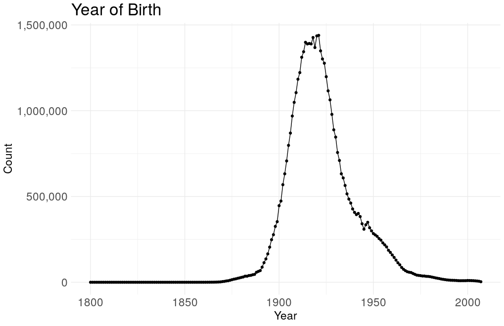

**bmonth**

**Label:** Birth Month

Description: bmonth is a numeric variable reporting the person’s month of birth, as recorded in the Numident death records.

| bmonth | label | n | freq % |
| --- | --- | --- | --- |
| 1 | January | 4181375 | 8.47 |
| 2 | February | 3933555 | 7.97 |
| 3 | March | 4296940 | 8.71 |
| 4 | April | 3976307 | 8.06 |
| 5 | May | 4051432 | 8.21 |
| 6 | June | 3937147 | 7.98 |
| 7 | July | 4221224 | 8.56 |
| 8 | August | 4362872 | 8.84 |
| 9 | September | 4279353 | 8.67 |
| 10 | October | 4173868 | 8.46 |
| 11 | November | 3884566 | 7.87 |
| 12 | December | 4039185 | 8.19 |
| NA | Missing | 3 | 0.00 |

**bday**

**Label**: Birth Day

**Description**: bday is a numeric variable reporting the person’s day of birth, as recorded in the Numident death records.

**Note:** It appears from the surplus of counts on the 1st and the 15th of the month that SSA might have done some imputation of missing values to these dates.

| bday | n | freq % |
| --- | --- | --- |
| 1 | 1752583 | 3.600 |
| 2 | 1658244 | 3.400 |
| 3 | 1609261 | 3.300 |
| 4 | 1637955 | 3.300 |
| 5 | 1622040 | 3.300 |
| 6 | 1626699 | 3.300 |
| 7 | 1605110 | 3.300 |
| 8 | 1631598 | 3.300 |
| 9 | 1590390 | 3.200 |
| 10 | 1710297 | 3.500 |
| 11 | 1586088 | 3.200 |
| 12 | 1670822 | 3.400 |
| 13 | 1568796 | 3.200 |
| 14 | 1621064 | 3.300 |
| 15 | 1782188 | 3.600 |
| 16 | 1613051 | 3.300 |
| 17 | 1604846 | 3.300 |
| 18 | 1616778 | 3.300 |
| 19 | 1576661 | 3.200 |
| 20 | 1643349 | 3.300 |
| 21 | 1546797 | 3.100 |
| 22 | 1631722 | 3.300 |
| 23 | 1592459 | 3.200 |
| 24 | 1591364 | 3.200 |
| 25 | 1657548 | 3.400 |
| 26 | 1568447 | 3.200 |
| 27 | 1577419 | 3.200 |
| 28 | 1624799 | 3.300 |
| 29 | 1471946 | 3.000 |
| 30 | 1414317 | 2.900 |
| 31 | 901308 | 1.800 |
| NA | 31881 | 0.065 |

**dyear**

**Label**: Death Year

**Description**: dyear is a numeric variable reporting the person’s year of death, as recorded in the Numident death records.

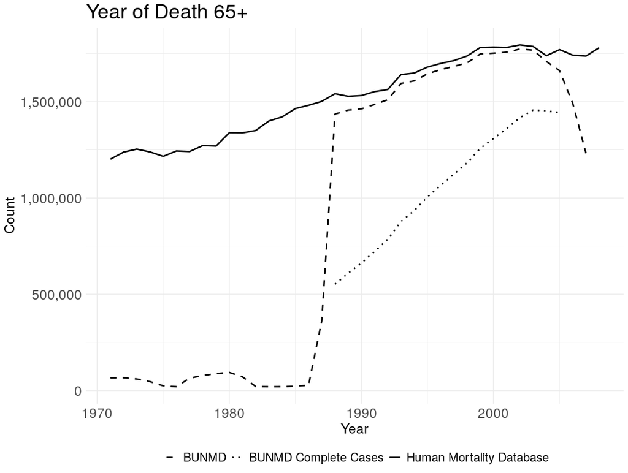

**dmonth**

**Label**: Death Month

**Description**: dmonth is a numeric variable reporting the person’s month of death, as recorded in the Numident death records.

| dmonth | label | n | freq % |
| --- | --- | --- | --- |
| 1 | January | 4610022 | 9.34 |
| 2 | February | 4119282 | 8.35 |
| 3 | March | 4353899 | 8.82 |
| 4 | April | 4036794 | 8.18 |
| 5 | May | 4023999 | 8.16 |
| 6 | June | 3828836 | 7.76 |
| 7 | July | 3924851 | 7.96 |
| 8 | August | 3887262 | 7.88 |
| 9 | September | 3835198 | 7.77 |
| 10 | October | 4125914 | 8.36 |
| 11 | November | 4102011 | 8.31 |
| 12 | December | 4489759 | 9.10 |

**dday**

**Label**: Day of Death

**Description**: dday is a numeric variable reporting the person’s day of death, as recorded in the Numident death records.

| dday | n | freq % |
| --- | --- | --- |
| 1 | 1432114 | 2.9 |
| 2 | 1240840 | 2.5 |
| 3 | 1258505 | 2.6 |
| 4 | 1281969 | 2.6 |
| 5 | 1241857 | 2.5 |
| 6 | 1238121 | 2.5 |
| 7 | 1234527 | 2.5 |
| 8 | 1237353 | 2.5 |
| 9 | 1234152 | 2.5 |
| 10 | 1236852 | 2.5 |
| 11 | 1234080 | 2.5 |
| 12 | 1234552 | 2.5 |
| 13 | 1230163 | 2.5 |
| 14 | 1231013 | 2.5 |
| 15 | 3392922 | 6.9 |
| 16 | 1227374 | 2.5 |
| 17 | 1228022 | 2.5 |
| 18 | 1223495 | 2.5 |
| 19 | 1223837 | 2.5 |
| 20 | 1230608 | 2.5 |
| 21 | 1218728 | 2.5 |
| 22 | 1217328 | 2.5 |
| 23 | 1219353 | 2.5 |
| 24 | 1216433 | 2.5 |
| 25 | 1214084 | 2.5 |
| 26 | 1216347 | 2.5 |
| 27 | 1215884 | 2.5 |
| 28 | 1217904 | 2.5 |
| 29 | 1130910 | 2.3 |
| 30 | 1104857 | 2.2 |
| 31 | 713927 | 1.4 |
| NA | 9559716 | 19.0 |

**death_age**

**Label**: Age at Death (Years)

**Description**: death_age is a numeric variable reporting the person’s age at death in years, calculated using birth and death information recorded in the Numident death records.

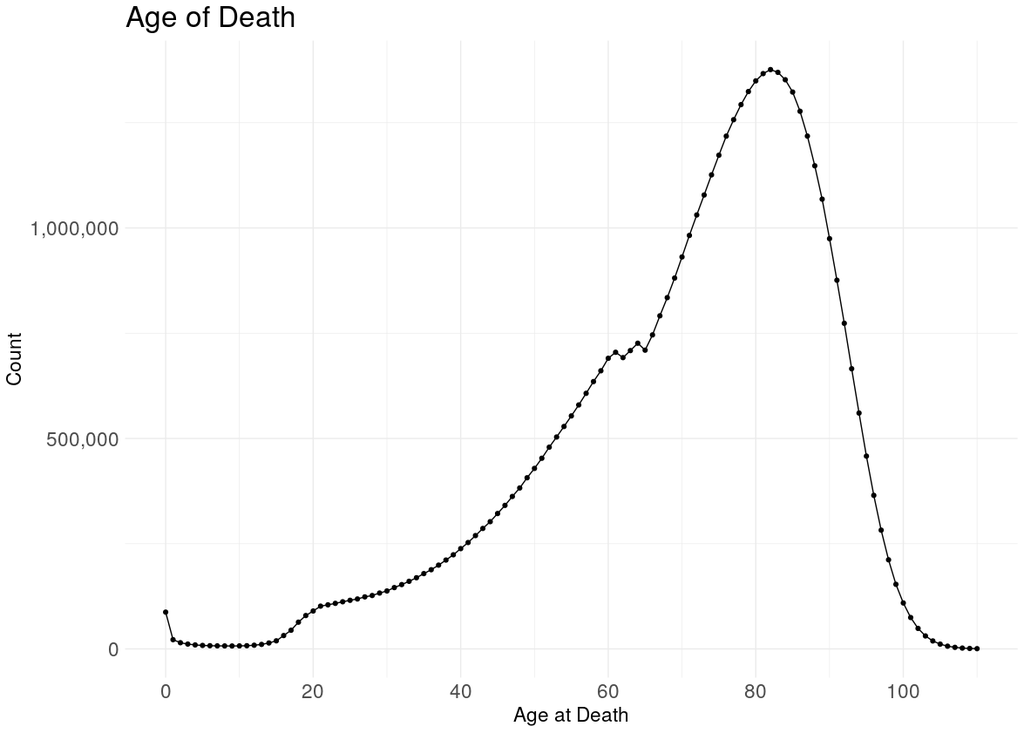

**zip_residence**

**Label**: ZIP Code of Residence at Time of Death

**Description**: zip_residence is a string variable (9-characters) reporting a person’s ZIP code of residence at time of death, as in the Numident death records.

**socstate**

**Label**: State where Social Security Number Issued

**Description**: The state in which the person’s social security card was issued. Determined by first three (3) digits of Social Security number, as recorded in Numident death records. The numeric codes match the detailed IPUMS-USA Birthplace codes.

| socstate | label | n | freq % |
| --- | --- | --- | --- |
| 3600 | New York | 4980871 | 10.0 |
| 4200 | Pennsylvania | 3266642 | 6.6 |
| 600 | California | 3255785 | 6.6 |
| 1700 | Illinois | 2855031 | 5.8 |
| NA | NA | 2707652 | 5.5 |
| 4800 | Texas | 2562712 | 5.2 |
| 3900 | Ohio | 2460960 | 5.0 |
| 2600 | Michigan | 2034399 | 4.1 |
| 3400 | New Jersey | 1510334 | 3.1 |
| 2500 | Massachusetts | 1465566 | 3.0 |
| 2900 | Missouri | 1299368 | 2.6 |
| 1800 | Indiana | 1248048 | 2.5 |
| 1300 | Georgia | 1171471 | 2.4 |
| 4700 | Tennessee | 1115600 | 2.3 |
| 1200 | Florida | 1043773 | 2.1 |
| 5500 | Wisconsin | 1021002 | 2.1 |
| 5100 | Virginia | 1014527 | 2.1 |
| 100 | Alabama | 1010756 | 2.0 |
| 2100 | Kentucky | 917858 | 1.9 |
| 2200 | Louisiana | 899017 | 1.8 |
| 2700 | Minnesota | 817858 | 1.7 |
| 4000 | Oklahoma | 779894 | 1.6 |
| 1900 | Iowa | 764643 | 1.5 |
| 2400 | Maryland | 728497 | 1.5 |
| 5300 | Washington | 675565 | 1.4 |

**father_fname**

**Label**: Father’s First Name

**Description**: father_fname is a character variable reporting the first 16 letters of the person’s father’s first name, as recorded in the Numident death records.

**father_mname**

**Label**: Father’s Middle Name

**Description**: father_mname is a character variable reporting the first 16 letters of the person’s father’s middle name, as recorded in the Numident death records.

**father_lname**

**Label**: Father’s Last Name

**Description**: father_lname is a character variable reporting the first 21 letters of the person’s father’s last name, as recorded in the Numident death records.

**mother_fname**

**Label**: Mother’s First Name

**Description**: mother_fname is a character variable reporting the first 16 letters of the person’s mother’s first name, as recorded in the Numident death records.

**mother_mname**

**Label**: Mother’s Middle Name

**mother_lname**

**Label**: Mother’s Last Name

**age_first_application**

**Label**: Age at First Social Security Application

**Description**: age_first_application reports the age at which the person submitted their first Social Security Application.

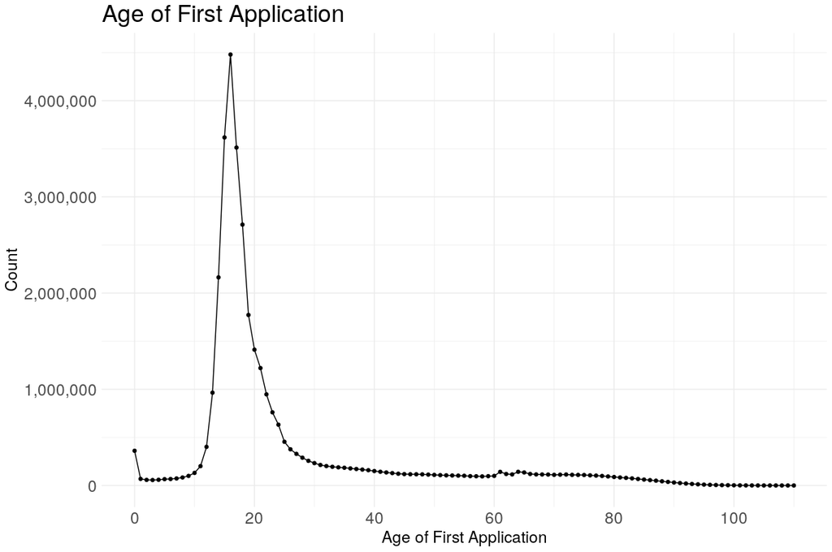

**number_apps**

**Label**: Total Number of Applications

**Description**: number_apps reports the person’s total number of Social Security applications, as recorded in the Numident application records. This variable was top-coded at 10.

| number_apps | n | freq % |
| --- | --- | --- |
| 0 | 14166703 | 29.000 |
| 1 | 17646617 | 36.000 |
| 2 | 10107569 | 20.000 |
| 3 | 4309930 | 8.700 |
| 4 | 1710582 | 3.500 |
| 5 | 719300 | 1.500 |
| 6 | 323112 | 0.650 |
| 7 | 155220 | 0.310 |
| 8 | 80363 | 0.160 |
| 9 | 43690 | 0.089 |
| 10 | 74741 | 0.150 |

**number_claims**

**Label**: Total Number of Claims

**Description**: number_claims reports the person’s total number of Social Security claims, as recorded in the Numident claim records. This variable was top-coded at 3.

| number_claims | n | freq % |
| --- | --- | --- |
| 0 | 32931311 | 66.75 |
| 1 | 16360228 | 33.16 |
| 2 | 45187 | 0.09 |
| 3+ | 1101 | 0.00 |

**weight**

**Label**: High Coverage Sample Weight

**Description**: A post-stratification person-weight to Human Mortality Database (HMD) totals for persons (1) born between 1895-1940 (2) dying between 1988-2005 and (3) dying between ages 65-100 (4) with a non-missing value for sex. Please see the CenSoc methods protocol for more details on weighting procedure.

| Value | Label |
| --- | --- |
| NA | No weight assigned |
| Min Weight | 0.961 |
| Max Weight | 2.383 |

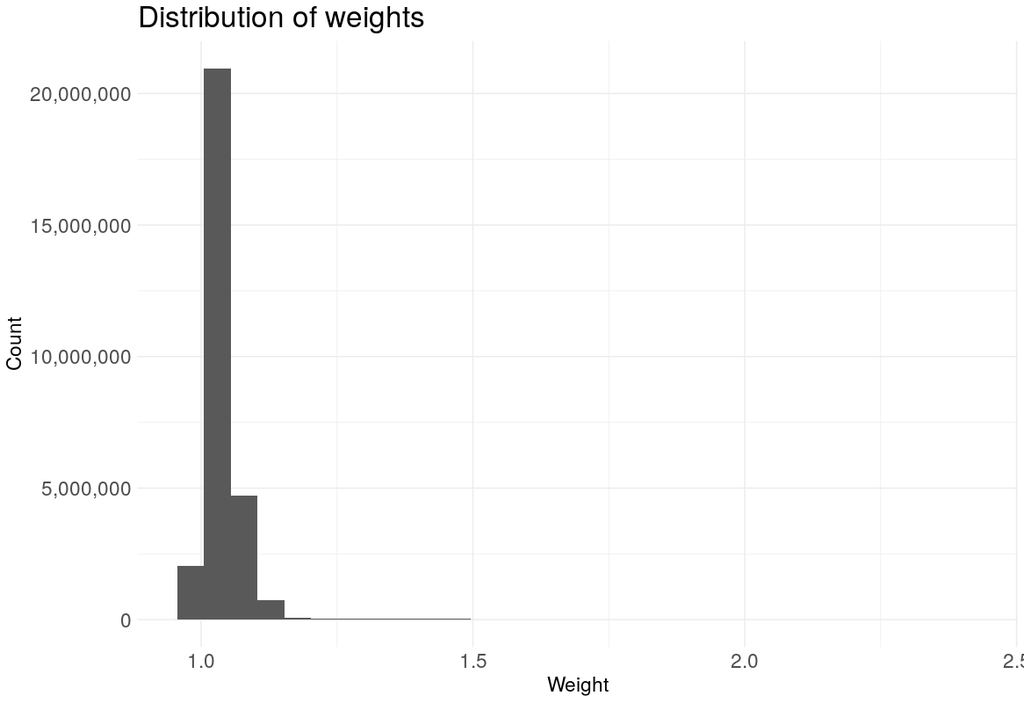

**ccweight**

**Label**: High Coverage “Complete Case” Sample Weight

**Description**: A post-stratification person-weight to Human Mortality Database (HMD) totals for persons (1) born between 1895-1940 (2) dying between 1988-2005 (3) dying between ages 65-100 (4) with a non-missing value for sex (5) with a non-missing value for birth place and (6) with a non-missing value for race. Please see the CenSoc methods protocol for more details on weighting procedure.

| Value | Label |
| --- | --- |
| NA | Incomplete case |
| Min Weight | 1.018 |
| Max Weight | 18.71 |

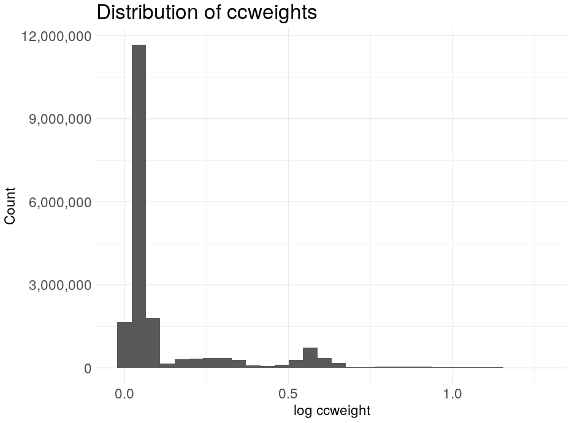